# Week 2: Potential Outcomes and Experiments

PS 813 - Causal Inference

Anton Strezhnev

strezhnev@wisc.edu

University of Wisconsin-Madison

January 25, 2027

$$\require{cancel}$$

## This week

- Defining **causal** estimands
  - The “potential outcomes” model of causation
- Causal **identification**
  - Linking **causal estimands** to observable quantities
- **Randomized experiments** as a solution to the identification problem
  - Treatment assignment is **independent** of the potential outcomes
- **Statistical inference** for completely randomized experiments
  - Neyman’s approach
  - Fisher’s approach

## The potential outcomes model

## Thinking about causal effects

- Two types of causal questions **(Gelman and Rubin, 2013)**
- **Causes of effects**
  - What are the factors that generate some outcome $Y$?
  - “Why?” questions: Why do states go to war? Why do politicians get re-elected?
- **Effects of causes**
  - If $X$ were to change, what might happen to $Y$?
  - **“What if?”** questions: If a politician were an incumbent, would they be more likely to be re-elected compared to if they were a non-incumbent?
- Our focus in this class is on **effects of causes**
  - Why? We can connect them to well-defined statistical quantities of interest (e.g. an “average treatment effect”)
  - “Causes of effects” are still important questions, but they’re more questions of **theory**

## Defining a causal effect

- Historically, causality was seen as a *deterministic* process.
  - **Hume (1740):** Causes are regularities in events of “constant conjunctions”
  - **Mill (1843):** Method of difference
- This became problematic – empirical observation alone does not demonstrate causality.
  - **Russell (1913):** Scientists aren’t interested in causality!
- How do we talk about causation that both incorporates *uncertainty* in measurement and clearly defines what we mean by **a “causal effect”**?

## The potential outcomes model

- **Rubin (1974)** - formalizes a framework for understanding causation from a statistical perspective.
  - Inspired by earlier **Neyman (1923)** and **Fisher (1935)** on randomized experiments.
- We’ll spend most of our time with this approach, often called the **Rubin Causal Model** or **potential outcomes** framework.
- **Core idea:**
  - Causal effects are effects of **interventions**
  - Causal effects are **contrasts** in **counterfactuals**
- The **potential outcomes** framework clarifies:
  1. **What** action is doing the causing?
  2. Compared to **what** alternative action?
  3. On **what** outcome metric?
  4. How would we learn about the effect from data?

## Statistical setup.

- Population of units
  - Finite population or infinite super-population
- Sample of $N$ units from the population indexed by $i$
- Observed outcome $Y_i$
- Binary treatment indicator $D_i$.
  - Units receiving “treatment”: $D_i = 1$
  - Units receiving “control”: $D_i = 0$
- Covariates (observed prior to treatment) $X_i$

## Potential outcomes

- The **potential outcome** $Y_i(d)$ is the value that the outcome would take if $D_i$ were set to $d$.
  - For binary $D_i$: $Y_i(1)$ is the value we would observe if unit $i$ were *treated*.
  - $Y_i(0)$ is the value we would observe if unit $i$ were under *control*
- We model the potential outcomes as **fixed** attributes of the units.
  - “Potential” in the sense that what is *actually* observed is a function of treatment assignment
- **Notation alert!** – Sometimes you’ll see potential outcomes written as:
  - $Y_i^1$, $Y_i^0$ or $Y_i^{d=1}$, $Y_i^{d=0}$
  - $Y_{i0}$, $Y_{i1}$
  - $Y_1(i)$, $Y_0(i)$
- Causal effects are contrasts in potential outcomes.
  - Individual treatment effect: $\tau_i = Y_i(1) - Y_i(0)$
  - Can consider ratios or other transformations (e.g. $\frac{Y_i(1)}{Y_i(0)}$)

## Consistency/SUTVA

- How do we link the potential outcomes to observed ones?
- Consistency/Stable Unit Treatment Value (SUTVA) assumption

  $$Y_i(d) = Y_i \text{ if } D_i = d$$
- Sometimes you’ll see this w/ binary $D_i$ (often in econometrics)

  $$Y_i = Y_i(1)D_i + Y_i(0)(1-D_i)$$
- Implications
  1. **No interference** - other units’ treatments don’t affect $i$’s potential outcomes.
  2. Single version of treatment
  3. $D$ is in principle manipulable - a “well-defined intervention”
  4. The means by which treatment is assigned is irrelevant (a version of 2)

## Positivity/Overlap

- We also need some assumptions on the treatment assignment mechanism $D_i$.
- In order to be able to observe *some units’* values of $Y_i(1)$ or $Y_i(0)$ treatment can’t be deterministic. For all $i$:

  $$0 < Pr(D_i = 1) < 1$$
- If no units could ever receive treatment or control it would be impossible to learn about $\mathbb{E}[Y_i | D_i = 1]$ or $\mathbb{E}[Y_i | D_i = 0]$
- This is sometimes called a **positivity** or overlap assumption.
  - Pretty trivial in a randomized experiment, but can be tricky in observational studies when $D_i$ is perfectly determined by some covariates $X_i$

## A missing data problem

- It’s useful to think of the causal inference problem in terms of *missingness* in the complete table of potential outcomes.

| Unit $i$ | Treatment $D_i$ | $Y_i(1)$ | $Y_i(0)$ | Observed $Y_i$ |
| --- | --- | --- | --- | --- |
| $1$ | $1$ | $5$ | ? | $5$ |
| $2$ | $0$ | ? | $-3$ | $-3$ |
| $3$ | $1$ | $9$ | ? | $9$ |
| $\vdots$ | $\vdots$ | $\vdots$ | $\vdots$ | $\vdots$ |
| $N$ | $0$ | ? | $8$ | $8$ |

- If we could observe both $Y_i(1)$ and $Y_i(0)$ for each unit, then this would be easy!
- But we can’t - we only observe what we’re given by $D_i$
- **Holland (1986)** calls this “The Fundamental Problem of Causal Inference”

## Causal Estimands

- The individual causal effect: $\tau_i$ (can’t identify this w/o strong assumptions!)

  $$\tau_i = Y_i(1) - Y_i(0)$$
- The **sample average treatment effect** (SATE): $\tau_s$

  $$\tau_s = \frac{1}{N}\sum_{i=1}^N Y_i(1) - Y_i(0)$$
- The **population average treatment effect** (PATE) $\tau_p$

  $$\tau_p = \mathbb{E}[Y_i(1) - Y_i(0)] = \mathbb{E}[Y_i(1)] - \mathbb{E}[Y_i(0)]$$

## Sample vs. Population Estimands

- With the SATE and PATE, we’ve made an important distinction between **two** sources of uncertainty
  - Random assignment of treatment (unobserved P.O.s)
  - Sampling from a population.
- Even if we’re just interested in the treatment effect **within** our sample, there’s still uncertainty
- When can we go from **SATE** to **PATE**?
  - If we have a random sample from the target population
  - If there are no sources of **effect heterogeneity** that differ between sample and target population
  - We’ll spend Week 3 talking about this problem - **external validity**

## Causal vs. Associational Estimands

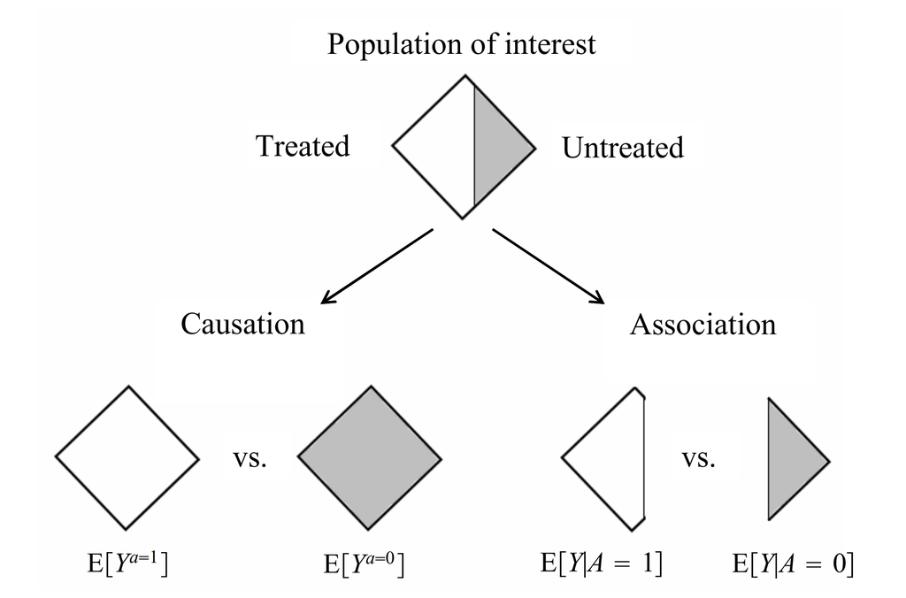

## Causal Identification

- **Causal identification**: Can we learn about the value of a causal effect from the observed data?
  - Can we express the causal estimand (e.g. $\tau_p = \mathbb{E}[Y_i(1) - Y_i(0)]$) entirely in terms of *observable* quantities?
- Causal identification comes prior to questions of estimation
  - It doesn’t matter whether you’re using regression, weighting, matching, doubly-robust estimation, double-LASSO, etc…
  - If you can’t answer the question “What’s your identification strategy?” then no amount of fancy stats will solve your problems.
- Identification requires *assumptions* about the connection between the observed data $Y_i$, $D_i$ and the unobserved counterfactuals $Y_i(d)$
  - (e.g.) Under what assumptions will the observed difference-in-means *identify* the average treatment effect?

## Identifying the ATT

- Suppose we want to identify the (population) Average Treatment Effect on the Treated (ATT)

  $$\tau_{\text{ATT}} = \mathbb{E}[Y_i(1) - Y_i(0) | D_i = 1]$$
- Let’s see what our consistency/SUTVA assumption gets us!
- First, let’s use linearity:

  $$\tau_{\text{ATT}} = \mathbb{E}[Y_i(1) | D_i = 1] - \mathbb{E}[Y_i(0) | D_i = 1]$$
- Next, consistency

  $$\tau_{\text{ATT}} = \mathbb{E}[Y_i | D_i = 1] - \mathbb{E}[Y_i(0) | D_i = 1]$$

## Identifying the ATT

- Still not enough though. We have an *unobserved* term $\mathbb{E}[Y_i(0) | D_i = 1]$. Why can’t we observe this directly?

  $$\tau_{\text{ATT}} = \mathbb{E}[Y_i | D_i = 1] - \mathbb{E}[Y_i(0) | D_i = 1]$$
- Let’s see what the difference would be between the ATT and the simple difference-in-means $\mathbb{E}[Y_i | D_i = 1] - \mathbb{E}[Y_i | D_i = 0]$. Add and subtract $\mathbb{E}[Y_i | D_i = 0]$

  $$\tau_{\text{ATT}} = \mathbb{E}[Y_i | D_i = 1] - \mathbb{E}[Y_i(0) | D_i = 1] - \mathbb{E}[Y_i | D_i = 0] + \mathbb{E}[Y_i | D_i = 0]$$
- Rearranging terms

  $$\tau_{\text{ATT}} = \bigg(\mathbb{E}[Y_i | D_i = 1] - \mathbb{E}[Y_i | D_i = 0]\bigg) - \bigg(\mathbb{E}[Y_i(0) | D_i = 1] - \mathbb{E}[Y_i | D_i = 0]\bigg)$$

## Identifying the ATT

- Now we have an expression for the ATT in terms of the difference-in-means and a bias term

  $$\tau_{\text{ATT}} = \underbrace{\bigg(\mathbb{E}[Y_i | D_i = 1] - \mathbb{E}[Y_i | D_i = 0]\bigg)}_{\text{Difference-in-means}} - \underbrace{\bigg(\mathbb{E}[Y_i(0) | D_i = 1] - \mathbb{E}[Y_i(0) | D_i = 0]\bigg)}_{\text{Selection-into-treatment bias}}$$
- What does this bias term represent? How can we interpret it?
  - How much higher are the potential outcomes under control for units that receive treatment vs. those that receive control.
  - Sometimes called a **selection-into-treatment** problem - units that choose treatment may have higher or lower potential outcomes than those that choose control.
- Can do the same analysis for the **average treatment effect** under **control** (ATC) and by extension the **average treatment effect**

## Selection-into-treatment bias

- Can use theory to **“sign the bias”**:
  - Suppose $Y_i$ was an indicator of **whether someone voted** in an election and $D_i$ was an indicator for whether they **received a political mailer**.
  - Consider a world where the mailer was sent out **non-randomly** to everyone **who had signed up** for a politician’s mailing list.
  - If we took the **difference in turnout rates** between voters who received the mailer and voters who did not receive the mailer, would we be **over-estimating** or **under-estimating** the effect of treatment?

## Ignorability/Unconfoundedness

- Suppose we want **point** identification and not just **bounds** on the causal effect?
  - What assumption can we make such that the **difference-in-means** **identifies** the ATT (or ATE)?
- **We assume**: the selection-into-treatment bias is $0$

  $$\mathbb{E}[Y_i(0) | D_i = 1] = \mathbb{E}[Y_i(0) | D_i = 0]$$

  $$\mathbb{E}[Y_i(1) | D_i = 1] = \mathbb{E}[Y_i(1) | D_i = 0]$$
- This will be true if treatment is **independent** of the potential outcomes.

  $$\{Y_i(1), Y_i(0)\} {\perp \! \! \! \perp} D_i$$
- Common names for this assumption: **exogeneity**, **unconfoundedness**, **ignorability**
  - *In simple terms*: Treatment is not **systematically more/less likely** to be assigned to units that have **higher/lower potential outcomes**.

## Ignorability/Unconfoundedness

- The **difference-in-means** identifies the **average treatment effect** under three assumptions:
  1. **Consistency/SUTVA**
  2. **Positivity/Overlap**
  3. **Ignorability/Unconfoundedness**
- Consistency gives us:

  $$\mathbb{E}[Y_i | D_i = 1] - \mathbb{E}[Y_i | D_i = 0] = \mathbb{E}[Y_i(1) | D_i = 1] - \mathbb{E}[Y_i(0) | D_i = 0]$$
- And ignorability gives us:

  $$\mathbb{E}[Y_i(1) | D_i = 1] - \mathbb{E}[Y_i(0) | D_i = 0] = \mathbb{E}[Y_i(1)] - \mathbb{E}[Y_i(0)] = \tau$$

## Ignorability/Unconfoundedness

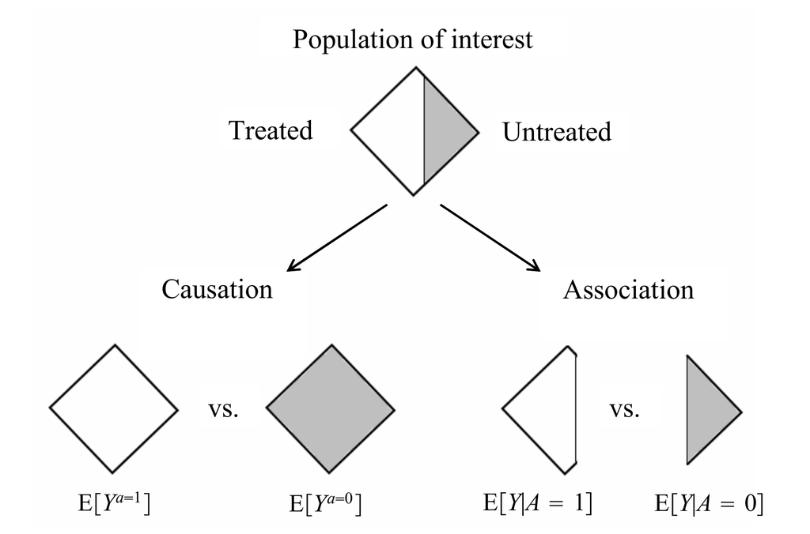

## Experiments

## Randomized Experiments

- What sort of research design **justifies ignorability**?
  - A **randomized experiment**!
- An **experiment** is any study where a researcher knows and controls the treatment assignment probability $Pr(D_i = 1)$
- A **randomized experiment** is an experiment that satisfies:
  - **Positivity**: $0 < Pr(D_i = 1) < 1$ for all units
  - **Ignorability**: $Pr(D_i = 1| \mathbf{Y}(1), \mathbf{Y}(0)) = Pr(D_i = 1)$
    - Another implication of $\mathbf{Y}(1), \mathbf{Y}(0) {\perp \! \! \! \perp} D_i$
    - Treatment assignment probabilities do not depend on the potential outcomes.

## Types of experiments

- Lots of ways in which we could design a randomized experiment where ignorability holds:
- Let $N_t$ be the number of treated units, $N_c$ number of controls
- **Bernoulli randomization**:
  - Independent coin flips for each $D_i$. $Pr(D_i = 1) = p$
  - $D_i {\perp \! \! \! \perp} D_j$ for all $i$, $j$.
  - $N_t$, $N_c$ are random variables
- **Complete randomization**
  - Fix $N_t$ and $N_c$ in advance. Randomly select $N_t$ units to be treated.
  - Each unit has an **equal probability** to be treated.
  - Each assignment with $N_t$ treated units is **equally likely** to occur
  - $D_i$ is independent of potential outcomes, but treatment assignment is slightly dependent across units.

## Types of experiments

- **Stratified randomization**
  - Using covariates $X_i$, form $J$ total **blocks** or **strata** of units with similar or identical covariate values.
  - Completely randomize *within* each of the $J$ blocks
  - In the limit, **pair**-randomization w/ strata of size $2$.
- **Cluster randomization**
  - Each unit $i$ belongs to some larger cluster. $C_i = \{1, 2, \dotsc, C\}$, $C < N$.
  - Treatment is assigned by **complete randomization** at the **cluster level**
    - Randomly select some number of clusters to be treated, remainder get control.
  - If units share cluster membership, they get the same treatment ($C_i = C_j \leadsto D_i = D_j$)

## Complete randomization

- How do we do **estimation** and **inference** under complete randomization?
  - We’ll start with the **finite-sample setting** and illustrate the **Neyman (1923)** approach to inference for the **SATE**.
- Define our quantity of interest, the **sample average treatment effect**

  $$\tau_{\text{s}} = \frac{1}{N}\sum_{i=1}^N Y_i(1) - Y_i(0)$$
- Our estimator is the sample difference-in-means.

  $$\hat{\tau} = \frac{1}{N_t} \sum_{i=1}^N Y_i D_i - \frac{1}{N_c} \sum_{i=1}^N Y_i (1 - D_i)$$

## Finite sample inference

- Consider a study with $N_t = 3$, $N_c = 3$ and suppose we could see the true “table of science”
  - Under one realization of the treatment $\mathbf{D}$, we have:

| Unit $i$ | Treatment $D_i$ | $Y_i(1)$ | $Y_i(0)$ | Observed $Y_i$ |
| --- | --- | --- | --- | --- |
| $1$ | $1$ | $1$ | $0$ | $1$ |
| $2$ | $0$ | $0$ | $1$ | $1$ |
| $3$ | $1$ | $1$ | $0$ | $1$ |
| $4$ | $0$ | $0$ | $1$ | $1$ |
| $5$ | $0$ | $0$ | $0$ | $0$ |
| $6$ | $1$ | $1$ | $1$ | $1$ |

- For this assignment, our realization of $\hat{\tau}$ (our estimate) would be:

  $$\frac{1 + 1 + 1}{3} - \frac{1 + 1 + 0}{3} = \frac{1}{3}$$

## Finite sample inference

- How about another, equally likely realization?

| Unit $i$ | Treatment $D_i$ | $Y_i(1)$ | $Y_i(0)$ | Observed $Y_i$ |
| --- | --- | --- | --- | --- |
| $1$ | $0$ | $1$ | $0$ | $0$ |
| $2$ | $0$ | $0$ | $1$ | $1$ |
| $3$ | $1$ | $1$ | $0$ | $1$ |
| $4$ | $1$ | $0$ | $1$ | $0$ |
| $5$ | $1$ | $0$ | $0$ | $0$ |
| $6$ | $0$ | $1$ | $1$ | $1$ |

- For this randomization, our realization of $\hat{\tau}$ would be:

  $$\frac{1 + 0 + 0}{3} - \frac{0 + 1 + 1}{3} = -\frac{1}{3}$$

## Finite sample inference

- Overall all possible randomizations, what is **the distribution**?
  - We can run a quick **simulation** and find out

```r
### Define the data frame
data <- data.frame(Y_1 = c(1,0,1,0,0,1),
                   Y_0 = c(0, 1, 0, 1, 0, 1))

## Simulate the sampling distribution
nIter = 10000
sate_est = rep(NA, nIter)
set.seed(53703)
for(i in 1:nIter){
  data$D = sample(rep(c(0,1), each=3))
  data$Y = data$D*data$Y_1 + (1-data$D)*data$Y_0
  sate_est[i] = mean(data$Y[data$D==1]) - mean(data$Y[data$D==0])
}
```

## Finite sample inference

- First, what’s the **expectation** of our estimator?

```r
mean(sate_est)
```

```
[1] -0.00387
```

- Next, what’s the **variance**?

```r
var(sate_est)
```

```
[1] 0.0661
```

## Finite sample inference

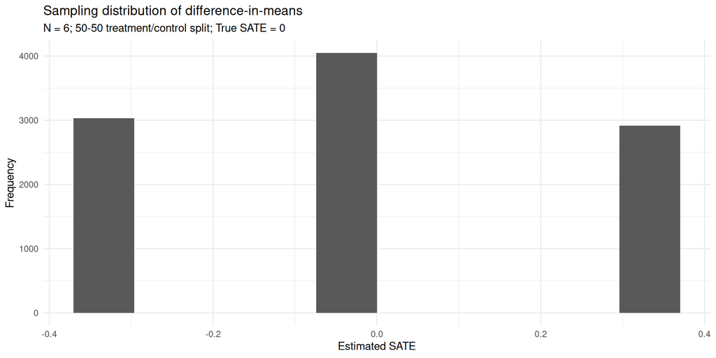

## Finite sample inference

- Of course, in real data, we only get one estimate.
  - Need to rely on **theory** to understand the *distribution* that estimate came from in order to do inference.
- Is $\hat{\tau}|\mathbf{Y}(1), \mathbf{Y}(0)$ unbiased for the SATE?
  - Under **complete randomization**: **Yes!**
- What is the sampling variance $Var(\hat{\tau})$ under a finite sample (fixed $\mathbf{Y}(1)$, $\mathbf{Y}(0)$)?
  - Surprisingly, depends on the **amount of effect heterogeneity**
- What should our estimator of the sampling variance $\widehat{Var(\hat{\tau})}$ be?
  - Our conventional variance estimator for the difference-in-means is **conservative**
  - Sadly, we can’t leverage the effect heterogeneity part (w/o more assumptions)!
  - Fundamental problem of causal inference strikes again!

## Unbiasedness

- Let’s show $\hat{\tau}$ is unbiased for the SATE. First, by linearity of expectations:

  $$\mathbb{E}[\hat{\tau} | \mathbf{Y}(1), \mathbf{Y}(0)] = \frac{1}{N_t} \sum_{i=1}^N \mathbb{E}\bigg[Y_i D_i \bigg| \mathbf{Y}(1), \mathbf{Y}(0)\bigg] - \frac{1}{N_c} \sum_{i=1}^N \mathbb{E}\bigg[Y_i (1 - D_i) \bigg| \mathbf{Y}(1), \mathbf{Y}(0) \bigg]$$
- By consistency $Y_iD_i = Y_i(1)D_i$ and $Y_i(1-D_i) = Y_i(0)(1-D_i)$

  $$\mathbb{E}[\hat{\tau}| \mathbf{Y}(1), \mathbf{Y}(0)] = \frac{1}{N_t} \sum_{i=1}^N \mathbb{E}\bigg[Y_i(1) D_i \bigg| \mathbf{Y}(1), \mathbf{Y}(0)\bigg] - \frac{1}{N_c} \sum_{i=1}^N \mathbb{E}\bigg[Y_i(0) (1 - D_i) \bigg| \mathbf{Y}(1), \mathbf{Y}(0)\bigg]$$
- Conditional on the potential outcomes, $Y_i(1)$ and $Y_i(0)$ are constants

  $$\mathbb{E}[\hat{\tau}| \mathbb{Y}(1), \mathbb{Y}(0)] = \frac{1}{N_t} \sum_{i=1}^N Y_i(1) \mathbb{E}\bigg[ D_i\bigg| \mathbb{Y}(1), \mathbb{Y}(0)\bigg] - \frac{1}{N_c} \sum_{i=1}^N Y_i(0) \mathbb{E}\bigg[(1 - D_i) \bigg| \mathbb{Y}(1), \mathbb{Y}(0)\bigg]$$

## Unbiasedness

- $D_i$ has a known distribution under complete randomization and its expectation is $Pr(D_i = 1)$, which is just $N_t/N$

  $$\mathbb{E}[\hat{\tau}| \mathbf{Y}(1), \mathbf{Y}(0)] = \frac{1}{N_t} \sum_{i=1}^N Y_i(1) \frac{N_t}{N} - \frac{1}{N_c} \sum_{i=1}^N Y_i(0) \frac{N_c}{N}$$
- Pulling out the constants

  $$\mathbb{E}[\hat{\tau}| \mathbf{Y}(1), \mathbf{Y}(0)] = \frac{1}{N} \sum_{i=1}^N Y_i(1) - \frac{1}{N} \sum_{i=1}^N Y_i(0)$$
- And we have the SATE!

  $$\mathbb{E}[\hat{\tau}| \mathbf{Y}(1), \mathbf{Y}(0)] = \frac{1}{N} \sum_{i=1}^N Y_i(1) - Y_i(0) = \tau_s$$

## Sampling variance

- What’s the variance of $\hat{\tau}$, conditional on the sample? Slightly tricky: $D_i$ is not independent of $D_j$

  $$Var\bigg(\hat{\tau}| \mathbf{Y}(1), \mathbf{Y}(0)\bigg) = \frac{S^2_t}{N_t} + \frac{S^2_c}{N_c} - \frac{S^2_{\tau_i}}{N}$$
- The **outcome variances** are:

  $$S_t^2 = \frac{1}{N-1} \sum_{i=1}^N \bigg(Y_i(1) - \bar{Y(1)}\bigg)^2$$
  $$S_c^2 = \frac{1}{N-1} \sum_{i=1}^N \bigg(Y_i(0) - \bar{Y(0)}\bigg)^2$$
- And the third term is the **sample variance** of the **treatment effects**

  $$S_{\tau_i}^2 = \frac{1}{N-1} \sum_{i=1}^N \bigg((Y_i(1) - Y_i(0))- (\bar{Y(1)} - \bar{Y(0)}) \bigg)^2$$

## Sampling variance

- Can we estimate the sampling variance?
- $S^2_t$ and $S^2_c$ can be estimated from their sample analogues (just the sample variances within treated/control groups)

  $$s_t^2 = \frac{1}{N_t-1} \sum_{i:D_i = 1} \bigg(Y_i(1) - \bar{Y_t^{\text{obs}}}\bigg)^2$$

  $$s_c^2 = \frac{1}{N_c-1} \sum_{i:D_i = 0} \bigg(Y_i(0) - \bar{Y_c^{\text{obs}}}\bigg)^2$$
- But…we can’t estimate $S^2_{\tau_i}$ directly from the sample!
  - The **fundamental problem of causal inference**! Can’t observe individual treatment effects.

## Neyman variance

- Neyman suggested just ignoring that third term and using our familiar estimator

  $$\widehat{\mathbb{V}}_{\text{Neyman}} = \frac{s_t^2}{N_t} + \frac{s_c^2}{N_c}$$
- What are its properties?
  - We know it’s **conservative** since $S_{\tau_i}^2 \ge 0$.
  - Confidence intervals using the Neyman standard error $\sqrt{\widehat{\mathbb{V}}_{\text{Neyman}}}$ will be **no smaller** than they should be.
  - If treatment effects are constant, it’s **unbiased**!

## Neyman variance

- Why do we see a difference between the true variance and the Neyman variance?
  - Let’s go back to our $N=6$ example!

| Unit $i$ | Treatment $D_i$ | $Y_i(1)$ | $Y_i(0)$ | Observed $Y_i$ |
| --- | --- | --- | --- | --- |
| $1$ | $1$ | $1$ | $0$ | $1$ |
| $2$ | $0$ | $0$ | $1$ | $1$ |
| $3$ | $1$ | $1$ | $0$ | $1$ |
| $4$ | $0$ | $0$ | $1$ | $1$ |
| $5$ | $0$ | $0$ | $0$ | $0$ |
| $6$ | $1$ | $1$ | $1$ | $1$ |

## Neyman variance

- The variance from our simulation was…

```r
var(sate_est)
```

```
[1] 0.0661
```

- We can verify our exact variance calculation from before…

```r
var(data$Y_1)/3 + var(data$Y_0)/3 - var(data$Y_1 - data$Y_0)/6
```

```
[1] 0.0667
```

- But if we ignore the variance of the treatment effects…

```r
var(data$Y_1)/3 + var(data$Y_0)/3
```

```
[1] 0.2
```

## Neyman variance

- When is the **Neyman variance** estimator unbiased/consistent for the true variance of $\hat{\tau}$?
  - When effects are **constant**…
  - …or when we’re targeting the **population** ATE (under a “random sampling” assumption)
- **Intuition:** With random sampling from a target population, can think of treated group and control group as two separate $N_t$ and $N_c$ size samples from the population $Y_i(1)$ and $Y_i(0)$ respectively.

## Illustration: Gerber, Green and Larimer (2008)

- **Gerber, Green and Larimer (2008)** want to know what causes people to vote.
  - What sorts of **encouragements** will get people to **turn out** more or less?
- **Five** treatment conditions in a randomized GOTV mailer experiment:
  - No mailer (0)
  - “Researchers will be studying your turnout” mailer (Hawthorne) (1)
  - “Voting is a civic duty” mailer (Civic Duty) (2)
  - “Your and your neighbors’ voting history” mailer (Neighbors) (3)
  - “Your turnout history” mailer (Self) (4)
- We’re going to analyze at the household level
  - Treatment is randomized by household - useful to analyze at the level of randomization.
  - Is $Y_i(d)$ well-defined for an individual? Somewhat tricky - likely spillovers across household members.

## Illustration: Gerber, Green and Larimer (2008)

```r
# Load the data
data <- read_dta('assets/data/ggr_2008_individual.dta')

# Aggregate to the household level
data_hh <- data %>% group_by(hh_id) %>% summarize(treatment = treatment[1], voted = mean(voted))

# For each treatment condition, calculate N and share voting
hh_means <- data_hh %>% group_by(treatment) %>% summarize(N = n(), voted = mean(voted))
kable(hh_means)
```

| treatment | N | voted |
| --- | --- | --- |
| 0 | 99999 | 0.304 |
| 1 | 20002 | 0.332 |
| 2 | 20001 | 0.325 |
| 3 | 20000 | 0.389 |
| 4 | 20000 | 0.357 |

## Illustration: Gerber, Green and Larimer (2008)

- Let’s estimate the ATE of the “Neighbors” treatment relative to control

```r
# Estimated ATE of Neighbors (3) vs. Control (0)
ate <- mean(data_hh$voted[data_hh$treatment == 3]) -
  mean(data_hh$voted[data_hh$treatment == 0])
ate
```

```
[1] 0.0848
```

- And let’s compute the Neyman variance

```r
# Estimate the sampling variance
var_ate = var(data_hh$voted[data_hh$treatment == 3])/sum(data_hh$treatment == 3) +
  var(data_hh$voted[data_hh$treatment == 0])/sum(data_hh$treatment == 0)

# Square root to get estimated SE
sqrt(var_ate)
```

```
[1] 0.0034
```

## Illustration: Gerber, Green and Larimer (2008)

- 95% asymptotic confidence interval and p-value against null of no ATE.

```r
# Confidence interval (assuming asymptotic normality)
ate_95CI = c(ate - qnorm(.975)*sqrt(var_ate),
  ate + qnorm(.975)*sqrt(var_ate))
ate_95CI
```

```
[1] 0.0781 0.0915
```

```r
# P-value H_0: \tau = 0, H_a: \tau \neq 0
p_val = 2*pnorm(-abs(ate/sqrt(var_ate)))
p_val
```

```
[1] 3.64e-137
```

## Illustration: Gerber, Green and Larimer (2008)

- Fun fact: You can get this via OLS regression!
  - OLS with a single binary regressor is just the difference-in-means.
  - Take care w/ inference: the classic OLS standard errors impose too many additional assumptions **(homoskedasticity)**
  - Heteroskedasticity-“robust” SEs are close to the Neyman variance in large samples…
  - …and **Samii and Aronow (2012)** show that the HC2 finite sample correction gets you the Neyman variance *exactly*.
- That’s the default for `lm_robust()` in the `estimatr` package!

```r
lm_robust(voted ~ I(treatment==3), data=data_hh %>% filter(treatment == 3|treatment == 0))
```

```
                      Estimate Std. Error t value  Pr(>|t|) CI Lower CI Upper
(Intercept)             0.3043    0.00132   230.2  0.00e+00   0.3017   0.3069
I(treatment == 3)TRUE   0.0848    0.00340    24.9 8.13e-137   0.0781   0.0915
                          DF
(Intercept)           119997
I(treatment == 3)TRUE 119997
```

## Fisher’s Exact Test

## Fisher’s Exact Test

- Neyman’s framework:
  - **Estimand**: Average Treatment Effect: $\tau = E[Y_i(1) - Y_i(0)]$
  - Difference-in-means estimator: Known expectation and sampling variance
  - **Hypothesis test.** Null of no ATE $H_0: \tau = 0$
  - Large sample/asymptotic theory to get the distribution of $\hat{\tau}$ to calculate p-values
- Fisher’s framework:
  - Can we get a p-value under (some) null hypothesis without the large-sample assumptions?
  - What does randomization alone justify?
  - Exact p-values under a *sharp* null of no individual treatment effect $Y_i(1) = Y_i(0)$ for all $i$.
  - **“Randomization test”** approach to p-values under a known randomization scheme.

## Hypothesis testing review

1. Define the null hypothesis.
   - Neyman framework: $H_0: \tau = \tau_0$
   - The probability of observing a particular value of the test statistic depends on what is “true” about the underlying parameter.
   - **Our thought experiment**: If the null were true, **how likely** would we see what we observe (or more extreme).
2. Choose a test statistic
   - In classical hypothesis testing, we pick something that has useful statistical properties:

     $$T = (\hat{\tau} - \tau_0)/\sqrt{\widehat{Var({\hat{\tau}})}}$$

## Hypothesis testing review

3. Determine the distribution of the test statistic under the null
   - In classical testing, by CLT, in large samples, $T \sim \mathcal{N}(0, 1)$
   - In smaller samples, you may have made further assumptions (e.g. outcome is normally distributed) to get an exact distribution (e.g. $t-$ distribution)
   - We need a **distribution** to compute **probabilities** from the CDF!
4. What is the probability of observing the test statistic $T$ that you observe in-sample (or a more extreme value) given the known distribution under the null?
   - That’s a **p-value**!

## What’s different about randomization testing?

1. Different null hypothesis (a **“sharp” null**)
2. No distributional assumptions/asymptotics to derive the distribution of $T$
   - We can instead literally just calculate the value under each possible realization of treatment.
   - And we know the distribution of treatment assignments because we **control them** in an experiment.

## Sharp null of no effect.

- The sharp null hypothesis states:

  $$H_0: \tau_i = Y_i(1) - Y_i(0) = 0 \text{ } \forall i$$
- Zero **individual-level** treatment effect for **all** units
- Sharp null implies zero ATE
  - But zero ATE does not imply sharp null!
- Why do we make this assumption?
  - Because now the observed data tells us **everything** we need to know about the potential outcomes

## The sharp null

- Remember our table of science? For a single realization of $\mathbf{D}$ we only observe half the potential outcomes?

| Unit $i$ | Treatment $D_i$ | $Y_i(1)$ | $Y_i(0)$ | Observed $Y_i$ |
| --- | --- | --- | --- | --- |
| $1$ | $1$ | $1$ | **?** | $1$ |
| $2$ | $0$ | **?** | $1$ | $1$ |
| $3$ | $1$ | $1$ | **?** | $1$ |
| $4$ | $0$ | **?** | $1$ | $1$ |
| $5$ | $0$ | **?** | $0$ | $0$ |
| $6$ | $1$ | $1$ | **?** | $1$ |

- But what does the sharp null imply about the unobserved potential outcomes? Can we fill in those question marks?

## The sharp null

- Yes! Under the sharp null, $Y_i(1) = Y_i(0)$

| Unit $i$ | Treatment $D_i$ | $Y_i(1)$ | $Y_i(0)$ | Observed $Y_i$ |
| --- | --- | --- | --- | --- |
| $1$ | $1$ | $1$ | $1$ | $1$ |
| $2$ | $0$ | $1$ | $1$ | $1$ |
| $3$ | $1$ | $1$ | $1$ | $1$ |
| $4$ | $0$ | $1$ | $1$ | $1$ |
| $5$ | $0$ | $0$ | $0$ | $0$ |
| $6$ | $1$ | $1$ | $1$ | $1$ |

- Why is this useful?
  - We can calculate the value of our test statistic *not only* under the observed $\mathbf{D}$ but under **all other possible** realizations of $\mathbf{D}$!

## The test statistic

- Our test statistic is any function of treatment assignments $\mathbf{D}$ and observed outcomes $\mathbf{Y}$.
- Lots of choices with different degrees of **power** for different kinds of treatment effects.
- We want to pick a test statistic that will return large values when the null is false and small values when it is true.
- A reasonable default: (absolute) **difference-in-means**

  $$t(\mathbf{D}, \mathbf{Y}) = \bigg|\frac{1}{N_t} \sum_{i=1}^N Y_i D_i - \frac{1}{N_c} \sum_{i=1}^N Y_i (1 - D_i) \bigg|$$
- What sorts of alternatives might this be bad for?
  - Offsetting positive and negative effects will return small values of $t(\mathbf{D}, \mathbf{Y})$ as would no effects.
  - We might pick a different test statistic in this case!

## The randomization distribution

- Under the sharp null, we can calculate $t(\mathbf{D}, \mathbf{Y})$ for every possible realization of $\mathbf{D}$.
  - Why? Because under the sharp null, observed $Y_i$ is unaffected by treatment assignment.
- Then to get a distribution for $t(\mathbf{D}, \mathbf{Y})$, we just need to know the distribution of $\mathbf{D}$. We know this by designing the experiment!
- We get our p-value by comparing the observed test statistic for our particular sample $t^*$ to the distribution of $t(\mathbf{D}, \mathbf{Y})$
  - For complete randomization, each of the $K$ possible realizations of $\mathbf{D}$ is equally likely, so we just enumerate all possible assignments $\mathbf{d} \in \Omega$ and calculate the share that are greater than our observed test statistic.

    $$Pr(t^* \ge t(\mathbf{D}, \mathbf{Y})) = \frac{\sum_{\mathbf{d} \in \Omega} \mathbb{I}(t(\mathbf{d}, \mathbf{Y}) \ge t^*)}{K}$$
- This is our p-value, which we compare to some threshold level $\alpha$ and reject the null when it’s below that level.

## Monte carlo approximation

- We could enumerate every possible treatment vector and actually just calculate $t(\mathbf{D}, \mathbf{Y})$.
- Even in fairly small samples this can involve quite a lot of computations! (e.g. ${20 \choose 10 } = 184756$)
- We’ll typically use a **monte carlo** approximation to the exact p-value.
  - This is also easier for more complicated randomization schemes.
- **Procedure:**
  - For $K$ iterations:
    1. Draw a realization of the treatment vector $\mathbf{d}_k$ from the known distribution of $\mathbf{D}$.
    2. Calculate the test statistic $t_k = t(\mathbf{d}_k, \mathbf{Y})$
  - Our p-value is the share of these $K$ test statistics that are greater than the observed $t^*$

## Putting it all together

- To do randomization inference under the sharp null
  1. Choose a test statistic
  2. Calculate the observed test statistic in your sample $t^* = t(\mathbf{D}, \mathbf{Y})$
  3. Draw another treatment vector $\mathbf{d}_1$ from the known distribution of $\mathbf{D}$
  4. Calculate $t_1 = t(\mathbf{d}_1, \mathbf{Y})$
  5. Repeat 3 and 4 as long as you want to get $K$ samples from the distribution of the test statistic under the null
  6. Calculate $p = \frac{1}{K}\sum_{i=1}^K \mathbb{I}(t_k \ge t^*)$

## Inverting tests to get confidence intervals

- Randomization tests alone give us p-values but no confidence intervals.
- **One approach:** “invert” the test - for what values of a “treatment effect” would we fail to reject the null
  - A $100(1-\alpha)\%$ confidence interval contains the set of parameter values for which an $\alpha$-level hypothesis test would fail to reject the null.
- **Slight complication:** We now need to actually define a “treatment effect” parameter:
  - For example, assume a *constant additive effect* for all units

    $$Y_i(1) - Y_i(0) = \tau_0$$
  - Our confidence set would be all of the values of $\tau_0$ for which we’d fail to reject the null
  - Calculate via a grid search through possible values of $\tau_0$.

## Conclusion

- We’ve learned two frameworks for estimating and conducting inference for treatment effects in randomized experiments
- **Neyman**
  - Define an estimand
    - the SATE: $\tau_s = \sum_{i=1}^N Y_i(1) - Y_i(0)$
    - the PATE: $\tau_p = \mathbb{E}[Y_i(1) - Y_i(0)]$
  - Choose an estimator
    - The difference-in-means
  - Estimator has known mean and variance under our design; asymptotically normal.
- **Fisher**
  - Forget the estimation process, let’s just do an (exact) test.
  - Sharp null of no effect ( $Y_i(1) = Y_i(0) \text{ } \forall i$ )
  - No large-sample approximations - inference justified by randomization alone

## Next week

- What can **break** your experiment?
  - Differential attrition
  - Non-compliance
  - Can we do **partial** identification/obtain **bounds**?
- How do we generalize from experiments?
  - Dimensions of **external validity**
  - How to think about **aggregating** knowledge from many studies?